# Reproducible Research: Peer Assessment 1

This assignment makes use of data from a personal activity monitoring device. This device collects data at 5 minute intervals through out the day. The data consists of two months of data from an anonymous individual collected during the months of October and November, 2012 and include the number of steps taken in 5 minute intervals each day.

### Environment setup for this analysis

```r
library('ggplot2')
library('timeDate')
# Set the seed
set.seed(10)
```

## Loading and preprocessing the data

The data available for this assignment is available as a **zip** file and it needs to be extracted

```r
# Unzip the file
unzip('./activity.zip')
# load the data
activity.data<-read.csv('./activity.csv')
summary(activity.data)
```

```
##      steps               date          interval
##  Min.   :  0.0   2012-10-01:  288   Min.   :   0
##  1st Qu.:  0.0   2012-10-02:  288   1st Qu.: 589
##  Median :  0.0   2012-10-03:  288   Median :1178
##  Mean   : 37.4   2012-10-04:  288   Mean   :1178
##  3rd Qu.: 12.0   2012-10-05:  288   3rd Qu.:1766
##  Max.   :806.0   2012-10-06:  288   Max.   :2355
##  NA's   :2304    (Other)   :15840
```

## What is mean total number of steps taken per day?

The data gives steps for 5 minutes intervals, so, daily summaries must be constructed to estimate the average number of steps per day.

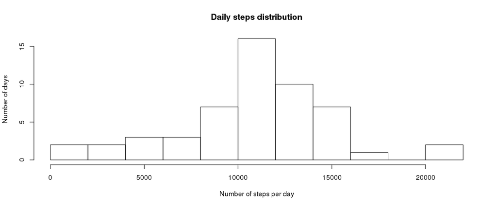

```r
# Calculate total daily steps
daily_summaries<-aggregate( data=activity.data,steps~date, sum)
# Mean daily steps. Rmove NA
me_daily<-mean(daily_summaries$steps,na.rm = TRUE)
# Median daily steps. Rmove NA
md_daily<-median(daily_summaries$steps,na.rm = TRUE)
# Histogram of daily number of steps
hist(daily_summaries$steps,breaks=10,
     main='Daily steps distribution',
     xlab='Number of steps per day',
     ylab='Number of days')
```

The mean number of steps per day were **10766** and the median number of steps per day were **10765**

## What is the average daily activity pattern?

For this summary we need to aggregate the data by the `interval` field.

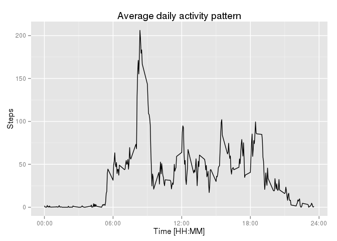

```r
daily.activity<-aggregate( data=activity.data,steps~interval, mean )
ggplot(daily.activity,aes(interval))+
  geom_line(aes(x=interval,y=steps))+
  ggtitle('Average daily activity pattern')+
  ylab('Steps')+
  xlab('Time [HH:MM]')+
  scale_x_continuous(breaks=c(0,600,1200,1800,2400),
                     labels=c('00:00','06:00','12:00','18:00','24:00'))
```

```r
max_steps<-max(daily.activity$steps)
max_interval<-daily.activity[which.max(daily.activity$steps),1]
```

The maximum average number of steps in a 5 minute interval is **206.1698** which corresponds to the interval ending at **0835**

## Imputing missing values

### Total number of missing values

```r
sum(is.na(activity.data$steps))
```

```
## [1] 2304
```

### Filling the missing values

From the analysis so far, it is clear that there is a diurnal pattern on the number of steps taken during a 5 minute interval. To fill missing values while minimising the impact on the data, we will use the following strategy:

```r
# New data frame to be filled
filled.activity.data<-activity.data
# Mean number of steps per interval
interval.mean<-aggregate( data=filled.activity.data,steps~interval, mean )
# Standard deviation of number of steps per interval
interval.sd<-aggregate( data=filled.activity.data,steps~interval, sd )
for (int in 1:length(interval.sd[,1])){
int=1
  # Number of missing data for this interval
  n_miss<-sum((filled.activity.data$interval==interval.sd[int,1])
              & (is.na(filled.activity.data$steps)))
  # Generate the replacement data
  samples<-rnorm(n_miss,interval.mean[int,2],interval.sd[int,2])
  # Replace the missing values
  filled.activity.data$steps[
    (filled.activity.data$interval==interval.sd[int,1])
    & (is.na(filled.activity.data$steps))]=samples
}
```

Summarizing these new data

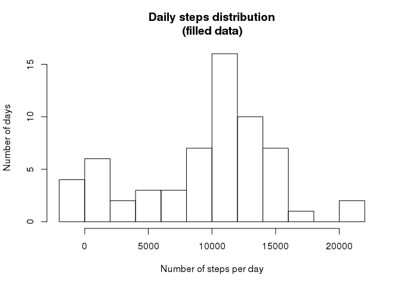

```r
# Calculate total daily steps
filled.daily_summaries<-aggregate( data=filled.activity.data,steps~date, sum)
# Mean daily steps. Rmove NA
filled.me_daily<-mean(filled.daily_summaries$steps,na.rm = TRUE)
# Median daily steps. Rmove NA
filled.md_daily<-median(filled.daily_summaries$steps,na.rm = TRUE)
# Histogram of daily number of steps
hist(filled.daily_summaries$steps,breaks=10,
     main='Daily steps distribution\n(filled data)',
     xlab='Number of steps per day',
     ylab='Number of days')
```

Comparing the results of filling against not filling the missing data

| Statistic | Raw data | Missing data replaced |
| --- | --- | --- |
| Mean | 10766 | 9354 |
| Median | 10765 | 10395 |

The result of filling the missing data was that the frequency of lower daily step counts which resulted in lower mean and median values.

## Are there differences in activity patterns between weekdays and weekends?

To facilitate this part of the analysis, a `timeDate` object was created using the `date` field.

```r
# Convert date field into timeDate object
timeDate_data<-timeDate(activity.data$date)
```

Adding a factor variable to separate weekday from weekend:

```r
filled.activity.data$daytype<-factor(
  isWeekday(timeDate_data),
  labels=c('Weekend','Weekday'))
```

Now summarizing the steps per interval for weekdays and weekends

```r
weekday.daily.activity<-aggregate( data=filled.activity.data,
                                   steps~interval+daytype, mean )
```

Comparing the diurnal profile for weekday and weekends:

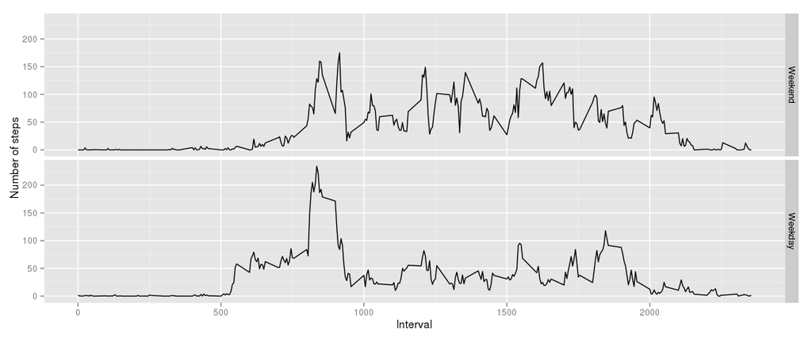

```r
ggplot(weekday.daily.activity)+
  geom_line(aes(x=interval, y=steps))+
  facet_grid(daytype ~. )+
  xlab('Interval')+
  ylab('Number of steps')
```